# Assignment 2

# 1.8 Building on top of the previous plot, show each Region in a different facet.

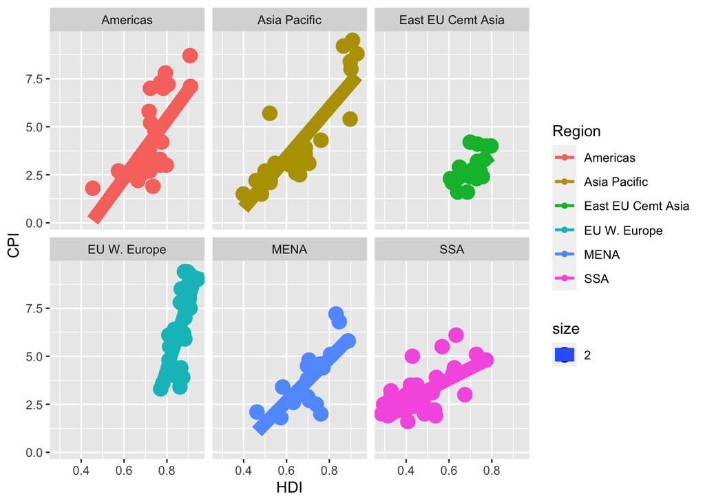

```r
ggplot(economist_data, aes(x=HDI, y=CPI, size=2, color=Region)) + geom_point() + geom_smooth(method=lm, se=FALSE) +
facet_wrap( ~ Region, nrow=2)
```

# 1.9 Show the distribution of HDI in each region using density plot. Set the transparency to 0.5

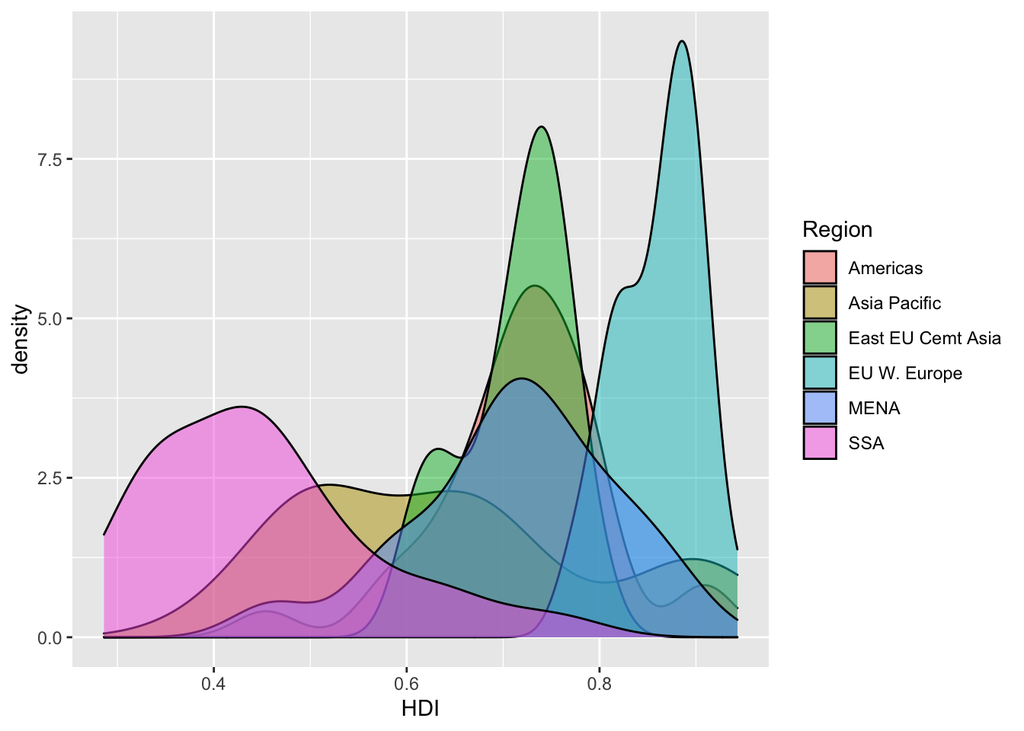

```r
ggplot(economist_data, aes(x=HDI, fill=Region)) + geom_density(alpha=0.5)
```

# 1.10 Show the distribution of HDI in each region using histogram and facetting.

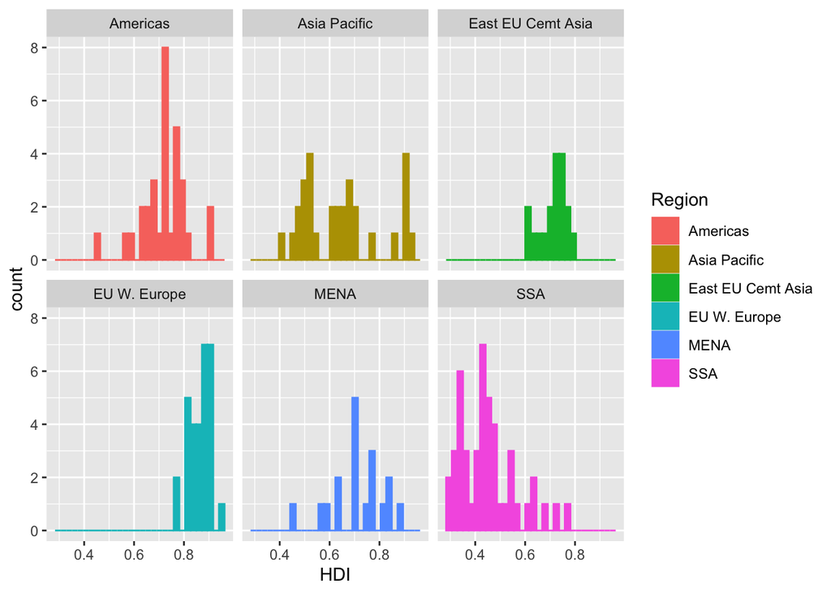

```r
ggplot(economist_data, aes(x=HDI, color=Region, fill=Region)) +
  geom_histogram() +
  facet_wrap( ~ Region, nrow=2)
```

# 1.11 Show the distribution of HDI in each region using a box plot. Set the transparency of these boxes to 0.5 and do not show outlier points with the box plot. Instead, show all data points for each country in the same plot. (Hint: geom_jitter() or position_jitter() might be useful.)

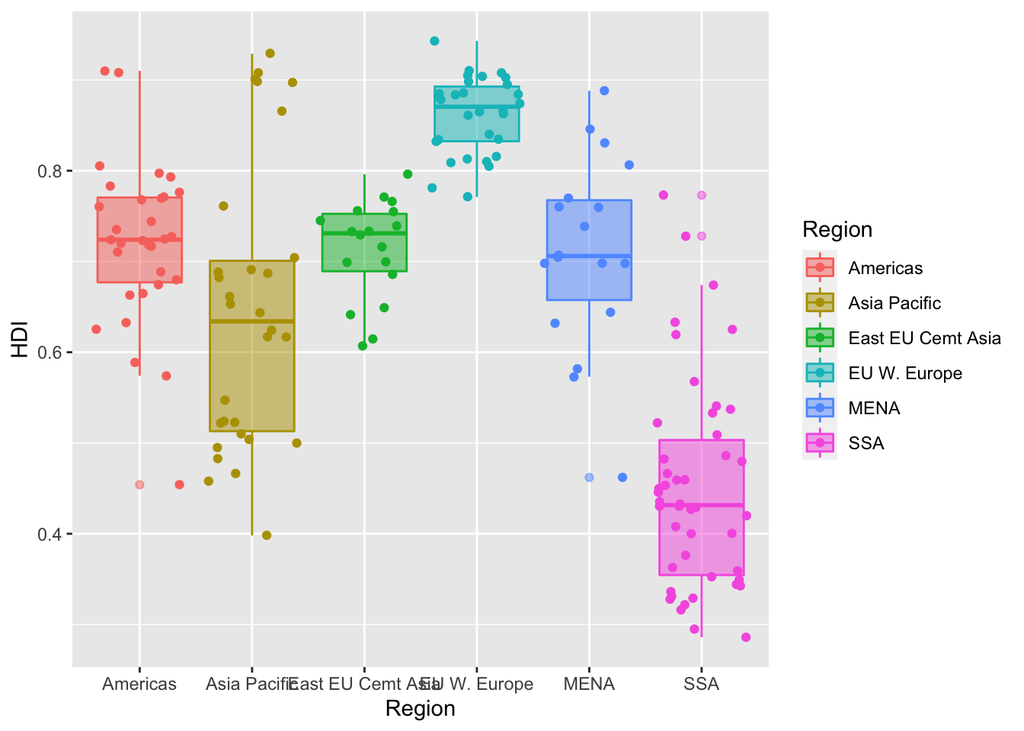

```r
ggplot(economist_data, aes(x=Region, y=HDI, fill=Region, color=Region)) +
  geom_boxplot(alpha=0.5) +
  geom_jitter()
```

# 1.12 Show the count of countries in each region using a bar plot.

[figure not shown]

```r
p<-ggplot(data=economist_data, aes(x=Region, y=as.factor(Region))) +
  geom_bar(stat="identity")
p +labs(x ="Region", y = "Count")
```

# 1.13 You have now created a variety of different plots of the same dataset. Which of your plots do you think are the most informative? Describe briefly the major trends that you see in the data.

# I believe that the scatterplots were the most informative with a large amount of data. Histograms and boxplots can get very cluttered (as seen in the homework) if there’s too much data that is being presented

# Exercise 2

# This excercise uses the dataset economics from the ggplot2 package. It was produced from US economic time series data available from http://research.stlouisfed.org/fred2. It descibes the number of unemployed persons (unemploy), among other variables, in the US from 1967 to 2015.

```r
head(economics) %>% kable()
```

| date | pce | pop | psavert | uempmed | unemploy |
| --- | --- | --- | --- | --- | --- |
| 1967-07-01 | 506.7 | 198712 | 12.6 | 4.5 | 2944 |
| 1967-08-01 | 509.8 | 198911 | 12.6 | 4.7 | 2945 |
| 1967-09-01 | 515.6 | 199113 | 11.9 | 4.6 | 2958 |
| 1967-10-01 | 512.2 | 199311 | 12.9 | 4.9 | 3143 |
| 1967-11-01 | 517.4 | 199498 | 12.8 | 4.7 | 3066 |
| 1967-12-01 | 525.1 | 199657 | 11.8 | 4.8 | 3018 |